# Multi-Path Stepwise Selection Demonstration

Lijuan Wang, Evan Jerome, Kira Noordwijk

2025-12-05

**GitHub Repository:** R-4-Data-Science/finalprojectgroup12

# Install R Package

```r
library(devtools)
remotes::install_github("R-4-Data-Science/finalprojectgroup12")
```

# Abstract

# 1. Linear Regression Example (Gaussian)

```r
# Simulate Gaussian data
n <- 80
p <- 6
X <- matrix(rnorm(n*p), n, p)
colnames(X) <- paste0("x", 1:p)
beta <- c(1.5, -1, 0, 0, 0.8, 0)
y <- as.numeric(X %*% beta + rnorm(n))

# Multi-path forward selection
forest <- build_paths(x = X, y = y, family = "gaussian", K = 6, eps = 1e-6, delta = 1, L = 50)

# Show top 5 models by AIC
kable(head(forest$aic_by_model,5), caption="Top 5 linear models by AIC", format="html")
```

Top 5 linear models by AIC

|  | key | aic | size | vars | formula |
| --- | --- | --- | --- | --- | --- |
| x1\|\|x2\|\|x5 | x1\|\|x2\|\|x5 | 213.8511 | 3 | x1, x2, x5 | y ~ x1 + x2 + x5 |
| x1\|\|x2\|\|x4\|\|x5 | x1\|\|x2\|\|x4\|\|x5 | 215.4531 | 4 | x1, x2, …. | y ~ x1 + x2 + x4 + x5 |
| x1\|\|x2\|\|x5\|\|x6 | x1\|\|x2\|\|x5\|\|x6 | 215.7269 | 4 | x1, x2, …. | y ~ x1 + x2 + x5 + x6 |
| x1\|\|x2\|\|x3\|\|x5 | x1\|\|x2\|\|x3\|\|x5 | 215.8407 | 4 | x1, x2, …. | y ~ x1 + x2 + x3 + x5 |
| x1\|\|x5 | x1\|\|x5 | 260.7436 | 2 | x1, x5 | y ~ x1 + x5 |

```r
# Stability estimation
stab <- stability(x = X, y = y, B = 20,
                  build_args = list(K = 6, eps = 1e-6, delta = 1, L = 50, family="gaussian"),
                  verbose = TRUE)
```

```
## Completed 10 / 20 resamples
```

```
## Completed 20 / 20 resamples
```

```r
stab_sorted <- sort(stab$pi, decreasing=TRUE)
kable(data.frame(variable=names(stab_sorted), stability=stab_sorted), caption="Variable Stability (Linear)", format="html")
```

Variable Stability (Linear)

|  | variable | stability |
| --- | --- | --- |
| x1 | x1 | 0.6960982 |
| x5 | x5 | 0.4537110 |
| x2 | x2 | 0.4148639 |
| x4 | x4 | 0.2419500 |
| x6 | x6 | 0.2374858 |
| x3 | x3 | 0.2369717 |

```r
# Plausible models
plaus <- plausible_models(forest, pi = stab$pi, Delta = 2, tau = 0.4)
kable(plaus, caption="Plausible linear models", format="html")
```

Plausible linear models

| key | aic | size | vars | formula | avg_stability |
| --- | --- | --- | --- | --- | --- |
| x1\|\|x2\|\|x5 | 213.8511 | 3 | x1, x2, x5 | y ~ x1 + x2 + x5 | 0.5215577 |
| x1\|\|x2\|\|x4\|\|x5 | 215.4531 | 4 | x1, x2, …. | y ~ x1 + x2 + x4 + x5 | 0.4516558 |
| x1\|\|x2\|\|x5\|\|x6 | 215.7269 | 4 | x1, x2, …. | y ~ x1 + x2 + x5 + x6 | 0.4505397 |
| x1\|\|x2\|\|x3\|\|x5 | 215.8407 | 4 | x1, x2, …. | y ~ x1 + x2 + x3 + x5 | 0.4504112 |

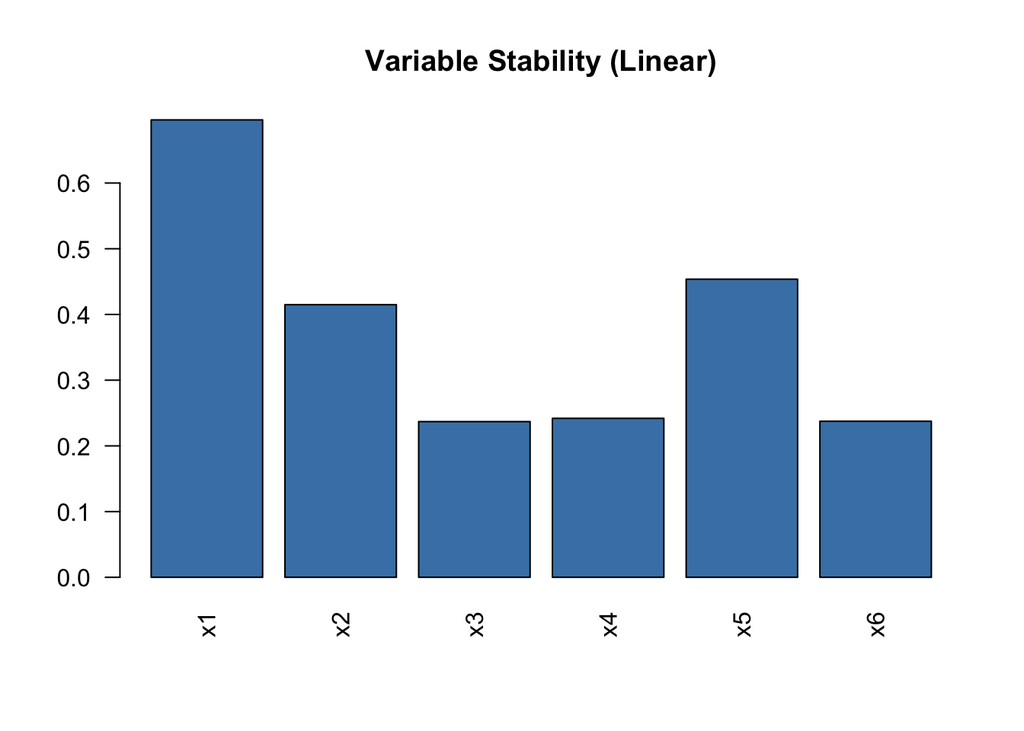

```r
# Visualize stability
barplot(stab$pi, main="Variable Stability (Linear)", col="steelblue", las=2)
```

# 2. Breast Cancer Data: Logistic Regression (Binomial)

```r
# Load Wisconsin Breast Cancer dataset
data("BreastCancer")
bc <- na.omit(BreastCancer)

# Encode outcomes: malignant=1, benign=0
y <- ifelse(bc$Class=="malignant",1,0)

# Drop ID and Class columns, convert to numeric
X_base_raw <- bc[, setdiff(names(bc), c("Id","Class"))]
X_base_raw <- as.data.frame(lapply(X_base_raw, function(col) as.numeric(as.character(col))))

# Standardize predictors
X_base <- as.data.frame(scale(X_base_raw))
rownames(X_base) <- NULL
n <- nrow(X_base)
p_base <- ncol(X_base)

# Generate quadratic and interaction terms
X_quad <- X_base^2
colnames(X_quad) <- paste0(colnames(X_base), "^2")

num_int <- p_base*(p_base-1)/2
X_int <- matrix(NA_real_, nrow=n, ncol=num_int)
int_names <- character(num_int)
k <- 1
for (i in 1:(p_base-1)) {
  for (j in (i+1):p_base) {
    X_int[,k] <- X_base[,i]*X_base[,j]
    int_names[k] <- paste0(colnames(X_base)[i], ":", colnames(X_base)[j])
    k <- k + 1
  }
}
colnames(X_int) <- int_names

# Combine features
X <- cbind(X_base, X_quad, X_int)

# Train/Test split
train_frac <- 0.8
n_train <- floor(train_frac*n)
train_idx <- sample(seq_len(n), n_train)
X_train <- X[train_idx, ]
y_train <- y[train_idx]
X_test <- X[-train_idx, ]
y_test <- y[-train_idx]

# Standardize column names
colnames(X_train) <- make.names(colnames(X_train))
colnames(X_test) <- make.names(colnames(X_test))

# Multi-path forward selection
forest_bin <- suppressWarnings(
  build_paths(x = X_train, y = y_train, family = "binomial", K = 5, eps = 1e-6, delta = 1, L = 50, keep_fits=TRUE)
)

# Show top 5 AIC models
forest_bin$aic_by_model <- forest_bin$aic_by_model[order(forest_bin$aic_by_model$aic), ]
kable(head(forest_bin$aic_by_model,5), caption="Top 5 Logistic Models by AIC", format="html")
```

Top 5 Logistic Models by AIC

|  | key | aic | size | vars | formula |
| --- | --- | --- | --- | --- | --- |
| Bare.nuclei\|\|Bl.cromatin\|\|Cell.size\|\|Cell.size.Bare.nuclei\|\|Cl.thickness | Bare.nuclei\|\|Bl.cromatin\|\|Cell.size\|\|Cell.size.Bare.nuclei\|\|Cl.thickness | 114.9086 | 5 | Bare.nuc…. | y ~ Bare.nuclei + Bl.cromatin + Cell.size + Cell.size.Bare.nuclei + Cl.thickness |
| Bare.nuclei\|\|Bl.cromatin\|\|Cell.size\|\|Cl.thickness\|\|Marg.adhesion | Bare.nuclei\|\|Bl.cromatin\|\|Cell.size\|\|Cl.thickness\|\|Marg.adhesion | 115.1802 | 5 | Bare.nuc…. | y ~ Bare.nuclei + Bl.cromatin + Cell.size + Cl.thickness + Marg.adhesion |
| Bare.nuclei\|\|Bl.cromatin\|\|Cell.size\|\|Cl.thickness\|\|Marg.adhesion.2 | Bare.nuclei\|\|Bl.cromatin\|\|Cell.size\|\|Cl.thickness\|\|Marg.adhesion.2 | 116.9341 | 5 | Bare.nuc…. | y ~ Bare.nuclei + Bl.cromatin + Cell.size + Cl.thickness + Marg.adhesion.2 |
| Bare.nuclei\|\|Bl.cromatin\|\|Cell.size\|\|Cl.thickness\|\|Normal.nucleoli | Bare.nuclei\|\|Bl.cromatin\|\|Cell.size\|\|Cl.thickness\|\|Normal.nucleoli | 117.8865 | 5 | Bare.nuc…. | y ~ Bare.nuclei + Bl.cromatin + Cell.size + Cl.thickness + Normal.nucleoli |
| Bare.nuclei\|\|Bl.cromatin\|\|Cell.size\|\|Cl.thickness\|\|Epith.c.size.Bare.nuclei | Bare.nuclei\|\|Bl.cromatin\|\|Cell.size\|\|Cl.thickness\|\|Epith.c.size.Bare.nuclei | 118.2743 | 5 | Bare.nuc…. | y ~ Bare.nuclei + Bl.cromatin + Cell.size + Cl.thickness + Epith.c.size.Bare.nuclei |

```r
# Stability estimation
stab_bin <- suppressWarnings(
  stability(x = X_train, y = y_train, B = 50, resample = "bootstrap",
            build_args = list(family="binomial", K=5, eps=1e-6, delta=1, L=50, keep_fits=FALSE))
)
stab_bin_sorted <- sort(stab_bin$pi, decreasing=TRUE)
kable(data.frame(variable=names(stab_bin_sorted), stability=stab_bin_sorted),
      caption="Variable Stability (Binomial)", format="html")
```

Variable Stability (Binomial)

|  | variable | stability |
| --- | --- | --- |
| Cell.size | Cell.size | 0.6533298 |
| Bare.nuclei | Bare.nuclei | 0.5569899 |
| Cl.thickness | Cl.thickness | 0.3240170 |
| Bl.cromatin | Bl.cromatin | 0.1564664 |
| Cell.shape | Cell.shape | 0.1552990 |
| Cell.size.Bare.nuclei | Cell.size.Bare.nuclei | 0.1132292 |
| Marg.adhesion | Marg.adhesion | 0.0735362 |
| Normal.nucleoli | Normal.nucleoli | 0.0521379 |
| Mitoses.2 | Mitoses.2 | 0.0473340 |
| Cell.shape.Marg.adhesion | Cell.shape.Marg.adhesion | 0.0354154 |
| Mitoses | Mitoses | 0.0298504 |
| Epith.c.size | Epith.c.size | 0.0286430 |
| Cl.thickness.2 | Cl.thickness.2 | 0.0268302 |
| Cell.size.Marg.adhesion | Cell.size.Marg.adhesion | 0.0266481 |
| Normal.nucleoli.2 | Normal.nucleoli.2 | 0.0261121 |
| Cl.thickness.Mitoses | Cl.thickness.Mitoses | 0.0229988 |
| Bare.nuclei.Mitoses | Bare.nuclei.Mitoses | 0.0229988 |
| Epith.c.size.Bare.nuclei | Epith.c.size.Bare.nuclei | 0.0223408 |
| Marg.adhesion.2 | Marg.adhesion.2 | 0.0223408 |
| Bare.nuclei.Normal.nucleoli | Bare.nuclei.Normal.nucleoli | 0.0218697 |
| Cl.thickness.Marg.adhesion | Cl.thickness.Marg.adhesion | 0.0215912 |
| Cell.size.2 | Cell.size.2 | 0.0192440 |
| Cell.shape.2 | Cell.shape.2 | 0.0192440 |
| Epith.c.size.2 | Epith.c.size.2 | 0.0192440 |
| Bare.nuclei.2 | Bare.nuclei.2 | 0.0192440 |
| Bl.cromatin.2 | Bl.cromatin.2 | 0.0192440 |
| Cl.thickness.Cell.size | Cl.thickness.Cell.size | 0.0192440 |
| Cl.thickness.Cell.shape | Cl.thickness.Cell.shape | 0.0192440 |
| Cl.thickness.Epith.c.size | Cl.thickness.Epith.c.size | 0.0192440 |
| Cl.thickness.Bare.nuclei | Cl.thickness.Bare.nuclei | 0.0192440 |
| Cl.thickness.Bl.cromatin | Cl.thickness.Bl.cromatin | 0.0192440 |
| Cl.thickness.Normal.nucleoli | Cl.thickness.Normal.nucleoli | 0.0192440 |
| Cell.size.Cell.shape | Cell.size.Cell.shape | 0.0192440 |
| Cell.size.Epith.c.size | Cell.size.Epith.c.size | 0.0192440 |
| Cell.size.Bl.cromatin | Cell.size.Bl.cromatin | 0.0192440 |
| Cell.size.Normal.nucleoli | Cell.size.Normal.nucleoli | 0.0192440 |
| Cell.size.Mitoses | Cell.size.Mitoses | 0.0192440 |
| Cell.shape.Epith.c.size | Cell.shape.Epith.c.size | 0.0192440 |
| Cell.shape.Bare.nuclei | Cell.shape.Bare.nuclei | 0.0192440 |
| Cell.shape.Bl.cromatin | Cell.shape.Bl.cromatin | 0.0192440 |
| Cell.shape.Normal.nucleoli | Cell.shape.Normal.nucleoli | 0.0192440 |
| Cell.shape.Mitoses | Cell.shape.Mitoses | 0.0192440 |
| Marg.adhesion.Epith.c.size | Marg.adhesion.Epith.c.size | 0.0192440 |
| Marg.adhesion.Bare.nuclei | Marg.adhesion.Bare.nuclei | 0.0192440 |
| Marg.adhesion.Bl.cromatin | Marg.adhesion.Bl.cromatin | 0.0192440 |
| Marg.adhesion.Normal.nucleoli | Marg.adhesion.Normal.nucleoli | 0.0192440 |
| Marg.adhesion.Mitoses | Marg.adhesion.Mitoses | 0.0192440 |
| Epith.c.size.Bl.cromatin | Epith.c.size.Bl.cromatin | 0.0192440 |
| Epith.c.size.Normal.nucleoli | Epith.c.size.Normal.nucleoli | 0.0192440 |
| Epith.c.size.Mitoses | Epith.c.size.Mitoses | 0.0192440 |
| Bare.nuclei.Bl.cromatin | Bare.nuclei.Bl.cromatin | 0.0192440 |
| Bl.cromatin.Normal.nucleoli | Bl.cromatin.Normal.nucleoli | 0.0192440 |
| Bl.cromatin.Mitoses | Bl.cromatin.Mitoses | 0.0192440 |
| Normal.nucleoli.Mitoses | Normal.nucleoli.Mitoses | 0.0192440 |

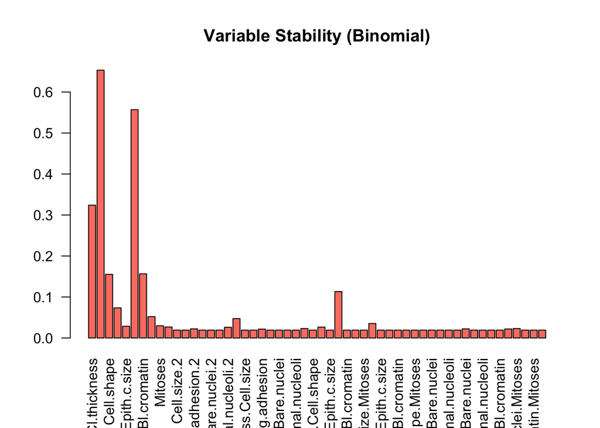

```r
# Visualize stability
barplot(stab_bin$pi, main="Variable Stability (Binomial)", col="salmon", las=2)
```

```r
# Plausible models
plaus_bin_jaccard <- plausible_models(forest_bin, pi=stab_bin$pi, Delta=15, tau=0.25, jaccard_thresh=0.9)
if(nrow(plaus_bin_jaccard)==0){
  message("Warning: no plausible models selected. Try adjusting Delta/tau.")
}else{
  kable(plaus_bin_jaccard, caption = "Plausible Logistic Models after Jaccard Deduplication", format = "html")
}
```

Plausible Logistic Models after Jaccard Deduplication

| key | aic | size | vars | formula | avg_stability |
| --- | --- | --- | --- | --- | --- |
| Bare.nuclei\|\|Bl.cromatin\|\|Cell.size\|\|Cell.size.Bare.nuclei\|\|Cl.thickness | 114.9086 | 5 | Bare.nuc…. | y ~ Bare.nuclei + Bl.cromatin + Cell.size + Cell.size.Bare.nuclei + Cl.thickness | 0.3608065 |
| Bare.nuclei\|\|Bl.cromatin\|\|Cell.size\|\|Cl.thickness\|\|Marg.adhesion | 115.1802 | 5 | Bare.nuc…. | y ~ Bare.nuclei + Bl.cromatin + Cell.size + Cl.thickness + Marg.adhesion | 0.3528679 |
| Bare.nuclei\|\|Bl.cromatin\|\|Cell.size\|\|Cl.thickness\|\|Marg.adhesion.2 | 116.9341 | 5 | Bare.nuc…. | y ~ Bare.nuclei + Bl.cromatin + Cell.size + Cl.thickness + Marg.adhesion.2 | 0.3426288 |
| Bare.nuclei\|\|Bl.cromatin\|\|Cell.size\|\|Cl.thickness\|\|Normal.nucleoli | 117.8865 | 5 | Bare.nuc…. | y ~ Bare.nuclei + Bl.cromatin + Cell.size + Cl.thickness + Normal.nucleoli | 0.3485882 |
| Bare.nuclei\|\|Bl.cromatin\|\|Cell.size\|\|Cl.thickness\|\|Epith.c.size.Bare.nuclei | 118.2743 | 5 | Bare.nuc…. | y ~ Bare.nuclei + Bl.cromatin + Cell.size + Cl.thickness + Epith.c.size.Bare.nuclei | 0.3426288 |
| Bare.nuclei\|\|Bl.cromatin\|\|Cell.size\|\|Cell.size.2\|\|Cl.thickness | 118.6824 | 5 | Bare.nuc…. | y ~ Bare.nuclei + Bl.cromatin + Cell.size + Cell.size.2 + Cl.thickness | 0.3420094 |
| Bare.nuclei\|\|Bl.cromatin\|\|Cell.size\|\|Cl.thickness\|\|Mitoses | 119.1582 | 5 | Bare.nuc…. | y ~ Bare.nuclei + Bl.cromatin + Cell.size + Cl.thickness + Mitoses | 0.3441307 |
| Bare.nuclei\|\|Bl.cromatin\|\|Cell.size\|\|Cl.thickness\|\|Normal.nucleoli.2 | 119.1602 | 5 | Bare.nuc…. | y ~ Bare.nuclei + Bl.cromatin + Cell.size + Cl.thickness + Normal.nucleoli.2 | 0.3433830 |
| Bare.nuclei\|\|Bl.cromatin\|\|Cell.size\|\|Cl.thickness\|\|Mitoses.2 | 119.2961 | 5 | Bare.nuc…. | y ~ Bare.nuclei + Bl.cromatin + Cell.size + Cl.thickness + Mitoses.2 | 0.3476274 |
| Bare.nuclei\|\|Bl.cromatin\|\|Cell.size\|\|Cl.thickness\|\|Epith.c.size.2 | 119.4382 | 5 | Bare.nuc…. | y ~ Bare.nuclei + Bl.cromatin + Cell.size + Cl.thickness + Epith.c.size.2 | 0.3420094 |
| Bare.nuclei\|\|Bl.cromatin\|\|Cell.size\|\|Cl.thickness\|\|Cl.thickness.Mitoses | 119.6188 | 5 | Bare.nuc…. | y ~ Bare.nuclei + Bl.cromatin + Cell.size + Cl.thickness + Cl.thickness.Mitoses | 0.3427604 |
| Bare.nuclei\|\|Bl.cromatin\|\|Cell.size\|\|Cell.size.Cell.shape\|\|Cl.thickness | 119.9534 | 5 | Bare.nuc…. | y ~ Bare.nuclei + Bl.cromatin + Cell.size + Cell.size.Cell.shape + Cl.thickness | 0.3420094 |
| Bare.nuclei\|\|Bl.cromatin\|\|Cell.shape\|\|Cell.size\|\|Cl.thickness | 120.1701 | 5 | Bare.nuc…. | y ~ Bare.nuclei + Bl.cromatin + Cell.shape + Cell.size + Cl.thickness | 0.3692204 |
| Bare.nuclei\|\|Bl.cromatin\|\|Cell.size\|\|Cl.thickness\|\|Epith.c.size | 120.3122 | 5 | Bare.nuc…. | y ~ Bare.nuclei + Bl.cromatin + Cell.size + Cl.thickness + Epith.c.size | 0.3438892 |
| Bare.nuclei\|\|Bl.cromatin\|\|Cell.shape.Bare.nuclei\|\|Cell.size\|\|Cl.thickness | 120.4734 | 5 | Bare.nuc…. | y ~ Bare.nuclei + Bl.cromatin + Cell.shape.Bare.nuclei + Cell.size + Cl.thickness | 0.3420094 |
| Bare.nuclei\|\|Bl.cromatin\|\|Cell.size\|\|Cl.thickness\|\|Cl.thickness.Bare.nuclei | 120.6735 | 5 | Bare.nuc…. | y ~ Bare.nuclei + Bl.cromatin + Cell.size + Cl.thickness + Cl.thickness.Bare.nuclei | 0.3420094 |
| Bare.nuclei\|\|Bl.cromatin\|\|Cell.size\|\|Cl.thickness | 120.7692 | 4 | Bare.nuc…. | y ~ Bare.nuclei + Bl.cromatin + Cell.size + Cl.thickness | 0.4227008 |
| Bare.nuclei\|\|Bl.cromatin\|\|Cell.shape.Marg.adhesion\|\|Cell.size\|\|Cl.thickness | 121.0951 | 5 | Bare.nuc…. | y ~ Bare.nuclei + Bl.cromatin + Cell.shape.Marg.adhesion + Cell.size + Cl.thickness | 0.3452437 |
| Bare.nuclei\|\|Bl.cromatin\|\|Cell.size\|\|Cl.thickness\|\|Cl.thickness.Marg.adhesion | 121.1796 | 5 | Bare.nuc…. | y ~ Bare.nuclei + Bl.cromatin + Cell.size + Cl.thickness + Cl.thickness.Marg.adhesion | 0.3424789 |
| Bare.nuclei\|\|Bl.cromatin\|\|Cell.size\|\|Cl.thickness\|\|Cl.thickness.Cell.size | 121.3775 | 5 | Bare.nuc…. | y ~ Bare.nuclei + Bl.cromatin + Cell.size + Cl.thickness + Cl.thickness.Cell.size | 0.3420094 |
| Bare.nuclei\|\|Bare.nuclei.2\|\|Bl.cromatin\|\|Cell.size\|\|Cl.thickness | 121.4284 | 5 | Bare.nuc…. | y ~ Bare.nuclei + Bare.nuclei.2 + Bl.cromatin + Cell.size + Cl.thickness | 0.3420094 |
| Bare.nuclei\|\|Bl.cromatin\|\|Cell.size\|\|Cl.thickness\|\|Cl.thickness.2 | 121.4393 | 5 | Bare.nuc…. | y ~ Bare.nuclei + Bl.cromatin + Cell.size + Cl.thickness + Cl.thickness.2 | 0.3435267 |
| Bare.nuclei\|\|Bl.cromatin\|\|Cell.size\|\|Cell.size.Marg.adhesion\|\|Cl.thickness | 121.4698 | 5 | Bare.nuc…. | y ~ Bare.nuclei + Bl.cromatin + Cell.size + Cell.size.Marg.adhesion + Cl.thickness | 0.3434902 |
| Bare.nuclei\|\|Bl.cromatin\|\|Cell.size\|\|Cl.thickness\|\|Marg.adhesion.Normal.nucleoli | 121.5413 | 5 | Bare.nuc…. | y ~ Bare.nuclei + Bl.cromatin + Cell.size + Cl.thickness + Marg.adhesion.Normal.nucleoli | 0.3420094 |
| Bare.nuclei\|\|Bl.cromatin\|\|Cell.size\|\|Cl.thickness\|\|Marg.adhesion.Epith.c.size | 121.6968 | 5 | Bare.nuc…. | y ~ Bare.nuclei + Bl.cromatin + Cell.size + Cl.thickness + Marg.adhesion.Epith.c.size | 0.3420094 |
| Bare.nuclei\|\|Bl.cromatin\|\|Cell.shape.Mitoses\|\|Cell.size\|\|Cl.thickness | 121.7579 | 5 | Bare.nuc…. | y ~ Bare.nuclei + Bl.cromatin + Cell.shape.Mitoses + Cell.size + Cl.thickness | 0.3420094 |
| Bare.nuclei\|\|Bl.cromatin\|\|Cell.size\|\|Cell.size.Mitoses\|\|Cl.thickness | 121.8559 | 5 | Bare.nuc…. | y ~ Bare.nuclei + Bl.cromatin + Cell.size + Cell.size.Mitoses + Cl.thickness | 0.3420094 |
| Bare.nuclei\|\|Bl.cromatin\|\|Cell.size\|\|Cl.thickness\|\|Cl.thickness.Bl.cromatin | 121.9736 | 5 | Bare.nuc…. | y ~ Bare.nuclei + Bl.cromatin + Cell.size + Cl.thickness + Cl.thickness.Bl.cromatin | 0.3420094 |
| Bare.nuclei\|\|Bl.cromatin\|\|Cell.size\|\|Cl.thickness\|\|Marg.adhesion.Bare.nuclei | 122.0033 | 5 | Bare.nuc…. | y ~ Bare.nuclei + Bl.cromatin + Cell.size + Cl.thickness + Marg.adhesion.Bare.nuclei | 0.3420094 |
| Bare.nuclei\|\|Bl.cromatin\|\|Cell.shape.Epith.c.size\|\|Cell.size\|\|Cl.thickness | 122.0542 | 5 | Bare.nuc…. | y ~ Bare.nuclei + Bl.cromatin + Cell.shape.Epith.c.size + Cell.size + Cl.thickness | 0.3420094 |
| Bare.nuclei\|\|Bl.cromatin\|\|Cell.size\|\|Cell.size.Epith.c.size\|\|Cl.thickness | 122.1825 | 5 | Bare.nuc…. | y ~ Bare.nuclei + Bl.cromatin + Cell.size + Cell.size.Epith.c.size + Cl.thickness | 0.3420094 |
| Bare.nuclei\|\|Bare.nuclei.Mitoses\|\|Bl.cromatin\|\|Cell.size\|\|Cl.thickness | 122.2194 | 5 | Bare.nuc…. | y ~ Bare.nuclei + Bare.nuclei.Mitoses + Bl.cromatin + Cell.size + Cl.thickness | 0.3427604 |
| Bare.nuclei\|\|Bare.nuclei.Normal.nucleoli\|\|Bl.cromatin\|\|Cell.size\|\|Cl.thickness | 122.2781 | 5 | Bare.nuc…. | y ~ Bare.nuclei + Bare.nuclei.Normal.nucleoli + Bl.cromatin + Cell.size + Cl.thickness | 0.3425346 |
| Bare.nuclei\|\|Bl.cromatin\|\|Bl.cromatin.2\|\|Cell.size\|\|Cl.thickness | 122.3084 | 5 | Bare.nuc…. | y ~ Bare.nuclei + Bl.cromatin + Bl.cromatin.2 + Cell.size + Cl.thickness | 0.3420094 |
| Bare.nuclei\|\|Bl.cromatin\|\|Cell.size\|\|Cl.thickness\|\|Cl.thickness.Normal.nucleoli | 122.3810 | 5 | Bare.nuc…. | y ~ Bare.nuclei + Bl.cromatin + Cell.size + Cl.thickness + Cl.thickness.Normal.nucleoli | 0.3420094 |
| Bare.nuclei\|\|Bl.cromatin\|\|Cell.size\|\|Cl.thickness\|\|Cl.thickness.Cell.shape | 122.3850 | 5 | Bare.nuc…. | y ~ Bare.nuclei + Bl.cromatin + Cell.size + Cl.thickness + Cl.thickness.Cell.shape | 0.3420094 |
| Bare.nuclei\|\|Bl.cromatin\|\|Cell.size\|\|Cl.thickness\|\|Marg.adhesion.Mitoses | 122.4062 | 5 | Bare.nuc…. | y ~ Bare.nuclei + Bl.cromatin + Cell.size + Cl.thickness + Marg.adhesion.Mitoses | 0.3420094 |
| Bare.nuclei\|\|Bl.cromatin\|\|Cell.shape.Normal.nucleoli\|\|Cell.size\|\|Cl.thickness | 122.4664 | 5 | Bare.nuc…. | y ~ Bare.nuclei + Bl.cromatin + Cell.shape.Normal.nucleoli + Cell.size + Cl.thickness | 0.3420094 |
| Bare.nuclei\|\|Bl.cromatin\|\|Cell.size\|\|Cl.thickness\|\|Epith.c.size.Normal.nucleoli | 122.4742 | 5 | Bare.nuc…. | y ~ Bare.nuclei + Bl.cromatin + Cell.size + Cl.thickness + Epith.c.size.Normal.nucleoli | 0.3420094 |
| Bare.nuclei\|\|Bl.cromatin\|\|Cell.shape.2\|\|Cell.size\|\|Cl.thickness | 122.5486 | 5 | Bare.nuc…. | y ~ Bare.nuclei + Bl.cromatin + Cell.shape.2 + Cell.size + Cl.thickness | 0.3420094 |
| Bare.nuclei\|\|Bl.cromatin\|\|Cell.size\|\|Cl.thickness\|\|Cl.thickness.Epith.c.size | 122.5567 | 5 | Bare.nuc…. | y ~ Bare.nuclei + Bl.cromatin + Cell.size + Cl.thickness + Cl.thickness.Epith.c.size | 0.3420094 |
| Bare.nuclei\|\|Bl.cromatin\|\|Cell.size\|\|Cl.thickness\|\|Normal.nucleoli.Mitoses | 122.5899 | 5 | Bare.nuc…. | y ~ Bare.nuclei + Bl.cromatin + Cell.size + Cl.thickness + Normal.nucleoli.Mitoses | 0.3420094 |
| Bare.nuclei\|\|Bare.nuclei.Bl.cromatin\|\|Bl.cromatin\|\|Cell.size\|\|Cl.thickness | 122.5994 | 5 | Bare.nuc…. | y ~ Bare.nuclei + Bare.nuclei.Bl.cromatin + Bl.cromatin + Cell.size + Cl.thickness | 0.3420094 |
| Bare.nuclei\|\|Bl.cromatin\|\|Cell.size\|\|Cl.thickness\|\|Epith.c.size.Mitoses | 122.6040 | 5 | Bare.nuc…. | y ~ Bare.nuclei + Bl.cromatin + Cell.size + Cl.thickness + Epith.c.size.Mitoses | 0.3420094 |
| Bare.nuclei\|\|Bl.cromatin\|\|Cell.size\|\|Cell.size.Normal.nucleoli\|\|Cl.thickness | 122.6060 | 5 | Bare.nuc…. | y ~ Bare.nuclei + Bl.cromatin + Cell.size + Cell.size.Normal.nucleoli + Cl.thickness | 0.3420094 |
| Bare.nuclei\|\|Bl.cromatin\|\|Cell.size\|\|Cl.thickness\|\|Marg.adhesion.Bl.cromatin | 122.6636 | 5 | Bare.nuc…. | y ~ Bare.nuclei + Bl.cromatin + Cell.size + Cl.thickness + Marg.adhesion.Bl.cromatin | 0.3420094 |
| Bare.nuclei\|\|Bl.cromatin\|\|Cell.shape.Bl.cromatin\|\|Cell.size\|\|Cl.thickness | 122.6804 | 5 | Bare.nuc…. | y ~ Bare.nuclei + Bl.cromatin + Cell.shape.Bl.cromatin + Cell.size + Cl.thickness | 0.3420094 |
| Bare.nuclei\|\|Bl.cromatin\|\|Bl.cromatin.Normal.nucleoli\|\|Cell.size\|\|Cl.thickness | 122.7376 | 5 | Bare.nuc…. | y ~ Bare.nuclei + Bl.cromatin + Bl.cromatin.Normal.nucleoli + Cell.size + Cl.thickness | 0.3420094 |
| Bare.nuclei\|\|Bl.cromatin\|\|Cell.size\|\|Cl.thickness\|\|Epith.c.size.Bl.cromatin | 122.7599 | 5 | Bare.nuc…. | y ~ Bare.nuclei + Bl.cromatin + Cell.size + Cl.thickness + Epith.c.size.Bl.cromatin | 0.3420094 |
| Bare.nuclei\|\|Bl.cromatin\|\|Bl.cromatin.Mitoses\|\|Cell.size\|\|Cl.thickness | 122.7683 | 5 | Bare.nuc…. | y ~ Bare.nuclei + Bl.cromatin + Bl.cromatin.Mitoses + Cell.size + Cl.thickness | 0.3420094 |
| Bare.nuclei\|\|Bl.cromatin\|\|Cell.size\|\|Cell.size.Bl.cromatin\|\|Cl.thickness | 122.7689 | 5 | Bare.nuc…. | y ~ Bare.nuclei + Bl.cromatin + Cell.size + Cell.size.Bl.cromatin + Cl.thickness | 0.3420094 |
| Bare.nuclei\|\|Cell.size\|\|Cell.size.Bare.nuclei\|\|Cl.thickness | 123.8272 | 4 | Bare.nuc…. | y ~ Bare.nuclei + Cell.size + Cell.size.Bare.nuclei + Cl.thickness | 0.4118915 |
| Bare.nuclei\|\|Cell.size\|\|Cl.thickness\|\|Normal.nucleoli | 124.1940 | 4 | Bare.nuc…. | y ~ Bare.nuclei + Cell.size + Cl.thickness + Normal.nucleoli | 0.3966187 |
| Bare.nuclei\|\|Cell.size\|\|Cl.thickness\|\|Marg.adhesion | 124.3047 | 4 | Bare.nuc…. | y ~ Bare.nuclei + Cell.size + Cl.thickness + Marg.adhesion | 0.4019682 |
| Bare.nuclei\|\|Cell.size\|\|Cl.thickness\|\|Normal.nucleoli.2 | 126.3043 | 4 | Bare.nuc…. | y ~ Bare.nuclei + Cell.size + Cl.thickness + Normal.nucleoli.2 | 0.3901122 |
| Bare.nuclei\|\|Cell.size\|\|Cl.thickness\|\|Marg.adhesion.2 | 128.1229 | 4 | Bare.nuc…. | y ~ Bare.nuclei + Cell.size + Cl.thickness + Marg.adhesion.2 | 0.3891694 |
| Bare.nuclei\|\|Cell.size\|\|Cell.size.2\|\|Cl.thickness | 128.7293 | 4 | Bare.nuc…. | y ~ Bare.nuclei + Cell.size + Cell.size.2 + Cl.thickness | 0.3883952 |
| Bare.nuclei\|\|Cell.shape\|\|Cell.size\|\|Cl.thickness | 129.0933 | 4 | Bare.nuc…. | y ~ Bare.nuclei + Cell.shape + Cell.size + Cl.thickness | 0.4224089 |
| Bare.nuclei\|\|Cell.size\|\|Cl.thickness\|\|Epith.c.size.Bare.nuclei | 129.1535 | 4 | Bare.nuc…. | y ~ Bare.nuclei + Cell.size + Cl.thickness + Epith.c.size.Bare.nuclei | 0.3891694 |
| Bare.nuclei\|\|Cell.size\|\|Cell.size.Cell.shape\|\|Cl.thickness | 129.5702 | 4 | Bare.nuc…. | y ~ Bare.nuclei + Cell.size + Cell.size.Cell.shape + Cl.thickness | 0.3883952 |
| Bare.nuclei\|\|Cell.size\|\|Cl.thickness\|\|Epith.c.size | 129.6637 | 4 | Bare.nuc…. | y ~ Bare.nuclei + Cell.size + Cl.thickness + Epith.c.size | 0.3907449 |

# 3. Test-Set Performance Evaluation

```r
if(nrow(plaus_bin_jaccard) > 0){

  # Non-empty plausible models

  plaus_models <- lapply(plaus_bin_jaccard$vars, function(vars) make.names(vars))
  plaus_models <- Filter(function(v) length(v) > 0, plaus_models)

  perf_list <- lapply(plaus_models, function(vars) {
    common_vars <- intersect(vars, colnames(X_train))
    fit <- glm(as.formula(paste("y ~", paste(common_vars, collapse="+"))),
               data=data.frame(y=y_train, X_train[,common_vars,drop=FALSE]), family=binomial())

    X_test_sub <- X_test[, common_vars, drop=FALSE]
    y_pred <- predict(fit, newdata=data.frame(X_test_sub), type="response")

    y_pred_class <- ifelse(y_pred > 0.5, 1, 0)
    tp <- sum(y_pred_class==1 & y_test==1)
    tn <- sum(y_pred_class==0 & y_test==0)
    fp <- sum(y_pred_class==1 & y_test==0)
    fn <- sum(y_pred_class==0 & y_test==1)
    accuracy <- (tp+tn)/length(y_test)
    sensitivity <- ifelse((tp+fn)==0, NA, tp/(tp+fn))
    specificity <- ifelse((tn+fp)==0, NA, tn/(tn+fp))


    data.frame(model=paste(common_vars, collapse = " + "), accuracy, sensitivity, specificity, Tp=tp, Tn=tn, Fp=fp, Fn=fn)
  })

  perf_df <- bind_rows(perf_list)
  kable(perf_df, caption = "Test-set Performance for Plausible Models", format = "html")

} else {
  message("No plausible models available for evaluation.")
}
```

Test-set Performance for Plausible Models

| model | accuracy | sensitivity | specificity | Tp | Tn | Fp | Fn |
| --- | --- | --- | --- | --- | --- | --- | --- |
| Bare.nuclei + Bl.cromatin + Cell.size + Cell.size.Bare.nuclei + Cl.thickness | 0.9854015 | 0.9574468 | 1.0000000 | 45 | 90 | 0 | 2 |
| Bare.nuclei + Bl.cromatin + Cell.size + Cl.thickness + Marg.adhesion | 0.9854015 | 0.9574468 | 1.0000000 | 45 | 90 | 0 | 2 |
| Bare.nuclei + Bl.cromatin + Cell.size + Cl.thickness + Marg.adhesion.2 | 0.9781022 | 0.9574468 | 0.9888889 | 45 | 89 | 1 | 2 |
| Bare.nuclei + Bl.cromatin + Cell.size + Cl.thickness + Normal.nucleoli | 0.9854015 | 0.9574468 | 1.0000000 | 45 | 90 | 0 | 2 |
| Bare.nuclei + Bl.cromatin + Cell.size + Cl.thickness + Epith.c.size.Bare.nuclei | 0.9854015 | 0.9574468 | 1.0000000 | 45 | 90 | 0 | 2 |
| Bare.nuclei + Bl.cromatin + Cell.size + Cell.size.2 + Cl.thickness | 0.9781022 | 0.9361702 | 1.0000000 | 44 | 90 | 0 | 3 |
| Bare.nuclei + Bl.cromatin + Cell.size + Cl.thickness + Mitoses | 0.9781022 | 0.9361702 | 1.0000000 | 44 | 90 | 0 | 3 |
| Bare.nuclei + Bl.cromatin + Cell.size + Cl.thickness + Normal.nucleoli.2 | 0.9781022 | 0.9361702 | 1.0000000 | 44 | 90 | 0 | 3 |
| Bare.nuclei + Bl.cromatin + Cell.size + Cl.thickness + Mitoses.2 | 0.9781022 | 0.9574468 | 0.9888889 | 45 | 89 | 1 | 2 |
| Bare.nuclei + Bl.cromatin + Cell.size + Cl.thickness + Epith.c.size.2 | 0.9781022 | 0.9574468 | 0.9888889 | 45 | 89 | 1 | 2 |
| Bare.nuclei + Bl.cromatin + Cell.size + Cl.thickness + Cl.thickness.Mitoses | 0.9781022 | 0.9361702 | 1.0000000 | 44 | 90 | 0 | 3 |
| Bare.nuclei + Bl.cromatin + Cell.size + Cell.size.Cell.shape + Cl.thickness | 0.9781022 | 0.9361702 | 1.0000000 | 44 | 90 | 0 | 3 |
| Bare.nuclei + Bl.cromatin + Cell.shape + Cell.size + Cl.thickness | 0.9927007 | 0.9787234 | 1.0000000 | 46 | 90 | 0 | 1 |
| Bare.nuclei + Bl.cromatin + Cell.size + Cl.thickness + Epith.c.size | 0.9854015 | 0.9574468 | 1.0000000 | 45 | 90 | 0 | 2 |
| Bare.nuclei + Bl.cromatin + Cell.shape.Bare.nuclei + Cell.size + Cl.thickness | 0.9781022 | 0.9361702 | 1.0000000 | 44 | 90 | 0 | 3 |
| Bare.nuclei + Bl.cromatin + Cell.size + Cl.thickness + Cl.thickness.Bare.nuclei | 0.9781022 | 0.9574468 | 0.9888889 | 45 | 89 | 1 | 2 |
| Bare.nuclei + Bl.cromatin + Cell.size + Cl.thickness | 0.9781022 | 0.9574468 | 0.9888889 | 45 | 89 | 1 | 2 |
| Bare.nuclei + Bl.cromatin + Cell.shape.Marg.adhesion + Cell.size + Cl.thickness | 0.9781022 | 0.9574468 | 0.9888889 | 45 | 89 | 1 | 2 |
| Bare.nuclei + Bl.cromatin + Cell.size + Cl.thickness + Cl.thickness.Marg.adhesion | 0.9781022 | 0.9574468 | 0.9888889 | 45 | 89 | 1 | 2 |
| Bare.nuclei + Bl.cromatin + Cell.size + Cl.thickness + Cl.thickness.Cell.size | 0.9708029 | 0.9361702 | 0.9888889 | 44 | 89 | 1 | 3 |
| Bare.nuclei + Bare.nuclei.2 + Bl.cromatin + Cell.size + Cl.thickness | 0.9927007 | 0.9787234 | 1.0000000 | 46 | 90 | 0 | 1 |
| Bare.nuclei + Bl.cromatin + Cell.size + Cl.thickness + Cl.thickness.2 | 0.9781022 | 0.9361702 | 1.0000000 | 44 | 90 | 0 | 3 |
| Bare.nuclei + Bl.cromatin + Cell.size + Cell.size.Marg.adhesion + Cl.thickness | 0.9708029 | 0.9361702 | 0.9888889 | 44 | 89 | 1 | 3 |
| Bare.nuclei + Bl.cromatin + Cell.size + Cl.thickness + Marg.adhesion.Normal.nucleoli | 0.9635036 | 0.9148936 | 0.9888889 | 43 | 89 | 1 | 4 |
| Bare.nuclei + Bl.cromatin + Cell.size + Cl.thickness + Marg.adhesion.Epith.c.size | 0.9781022 | 0.9574468 | 0.9888889 | 45 | 89 | 1 | 2 |
| Bare.nuclei + Bl.cromatin + Cell.shape.Mitoses + Cell.size + Cl.thickness | 0.9708029 | 0.9361702 | 0.9888889 | 44 | 89 | 1 | 3 |
| Bare.nuclei + Bl.cromatin + Cell.size + Cell.size.Mitoses + Cl.thickness | 0.9781022 | 0.9574468 | 0.9888889 | 45 | 89 | 1 | 2 |
| Bare.nuclei + Bl.cromatin + Cell.size + Cl.thickness + Cl.thickness.Bl.cromatin | 0.9854015 | 0.9574468 | 1.0000000 | 45 | 90 | 0 | 2 |
| Bare.nuclei + Bl.cromatin + Cell.size + Cl.thickness + Marg.adhesion.Bare.nuclei | 0.9781022 | 0.9574468 | 0.9888889 | 45 | 89 | 1 | 2 |
| Bare.nuclei + Bl.cromatin + Cell.shape.Epith.c.size + Cell.size + Cl.thickness | 0.9781022 | 0.9574468 | 0.9888889 | 45 | 89 | 1 | 2 |
| Bare.nuclei + Bl.cromatin + Cell.size + Cell.size.Epith.c.size + Cl.thickness | 0.9781022 | 0.9574468 | 0.9888889 | 45 | 89 | 1 | 2 |
| Bare.nuclei + Bare.nuclei.Mitoses + Bl.cromatin + Cell.size + Cl.thickness | 0.9781022 | 0.9574468 | 0.9888889 | 45 | 89 | 1 | 2 |
| Bare.nuclei + Bare.nuclei.Normal.nucleoli + Bl.cromatin + Cell.size + Cl.thickness | 0.9781022 | 0.9574468 | 0.9888889 | 45 | 89 | 1 | 2 |
| Bare.nuclei + Bl.cromatin + Bl.cromatin.2 + Cell.size + Cl.thickness | 0.9781022 | 0.9574468 | 0.9888889 | 45 | 89 | 1 | 2 |
| Bare.nuclei + Bl.cromatin + Cell.size + Cl.thickness + Cl.thickness.Normal.nucleoli | 0.9708029 | 0.9361702 | 0.9888889 | 44 | 89 | 1 | 3 |
| Bare.nuclei + Bl.cromatin + Cell.size + Cl.thickness + Cl.thickness.Cell.shape | 0.9781022 | 0.9574468 | 0.9888889 | 45 | 89 | 1 | 2 |
| Bare.nuclei + Bl.cromatin + Cell.size + Cl.thickness + Marg.adhesion.Mitoses | 0.9781022 | 0.9574468 | 0.9888889 | 45 | 89 | 1 | 2 |
| Bare.nuclei + Bl.cromatin + Cell.shape.Normal.nucleoli + Cell.size + Cl.thickness | 0.9781022 | 0.9574468 | 0.9888889 | 45 | 89 | 1 | 2 |
| Bare.nuclei + Bl.cromatin + Cell.size + Cl.thickness + Epith.c.size.Normal.nucleoli | 0.9781022 | 0.9574468 | 0.9888889 | 45 | 89 | 1 | 2 |
| Bare.nuclei + Bl.cromatin + Cell.shape.2 + Cell.size + Cl.thickness | 0.9781022 | 0.9574468 | 0.9888889 | 45 | 89 | 1 | 2 |
| Bare.nuclei + Bl.cromatin + Cell.size + Cl.thickness + Cl.thickness.Epith.c.size | 0.9781022 | 0.9574468 | 0.9888889 | 45 | 89 | 1 | 2 |
| Bare.nuclei + Bl.cromatin + Cell.size + Cl.thickness + Normal.nucleoli.Mitoses | 0.9781022 | 0.9574468 | 0.9888889 | 45 | 89 | 1 | 2 |
| Bare.nuclei + Bare.nuclei.Bl.cromatin + Bl.cromatin + Cell.size + Cl.thickness | 0.9781022 | 0.9574468 | 0.9888889 | 45 | 89 | 1 | 2 |
| Bare.nuclei + Bl.cromatin + Cell.size + Cl.thickness + Epith.c.size.Mitoses | 0.9781022 | 0.9574468 | 0.9888889 | 45 | 89 | 1 | 2 |
| Bare.nuclei + Bl.cromatin + Cell.size + Cell.size.Normal.nucleoli + Cl.thickness | 0.9781022 | 0.9574468 | 0.9888889 | 45 | 89 | 1 | 2 |
| Bare.nuclei + Bl.cromatin + Cell.size + Cl.thickness + Marg.adhesion.Bl.cromatin | 0.9781022 | 0.9574468 | 0.9888889 | 45 | 89 | 1 | 2 |
| Bare.nuclei + Bl.cromatin + Cell.shape.Bl.cromatin + Cell.size + Cl.thickness | 0.9854015 | 0.9574468 | 1.0000000 | 45 | 90 | 0 | 2 |
| Bare.nuclei + Bl.cromatin + Bl.cromatin.Normal.nucleoli + Cell.size + Cl.thickness | 0.9781022 | 0.9574468 | 0.9888889 | 45 | 89 | 1 | 2 |
| Bare.nuclei + Bl.cromatin + Cell.size + Cl.thickness + Epith.c.size.Bl.cromatin | 0.9781022 | 0.9574468 | 0.9888889 | 45 | 89 | 1 | 2 |
| Bare.nuclei + Bl.cromatin + Bl.cromatin.Mitoses + Cell.size + Cl.thickness | 0.9781022 | 0.9574468 | 0.9888889 | 45 | 89 | 1 | 2 |
| Bare.nuclei + Bl.cromatin + Cell.size + Cell.size.Bl.cromatin + Cl.thickness | 0.9781022 | 0.9574468 | 0.9888889 | 45 | 89 | 1 | 2 |
| Bare.nuclei + Cell.size + Cell.size.Bare.nuclei + Cl.thickness | 0.9854015 | 0.9574468 | 1.0000000 | 45 | 90 | 0 | 2 |
| Bare.nuclei + Cell.size + Cl.thickness + Normal.nucleoli | 0.9854015 | 0.9574468 | 1.0000000 | 45 | 90 | 0 | 2 |
| Bare.nuclei + Cell.size + Cl.thickness + Marg.adhesion | 0.9854015 | 0.9574468 | 1.0000000 | 45 | 90 | 0 | 2 |
| Bare.nuclei + Cell.size + Cl.thickness + Normal.nucleoli.2 | 0.9781022 | 0.9361702 | 1.0000000 | 44 | 90 | 0 | 3 |
| Bare.nuclei + Cell.size + Cl.thickness + Marg.adhesion.2 | 0.9781022 | 0.9361702 | 1.0000000 | 44 | 90 | 0 | 3 |
| Bare.nuclei + Cell.size + Cell.size.2 + Cl.thickness | 0.9854015 | 0.9574468 | 1.0000000 | 45 | 90 | 0 | 2 |
| Bare.nuclei + Cell.shape + Cell.size + Cl.thickness | 0.9854015 | 0.9574468 | 1.0000000 | 45 | 90 | 0 | 2 |
| Bare.nuclei + Cell.size + Cl.thickness + Epith.c.size.Bare.nuclei | 0.9854015 | 0.9574468 | 1.0000000 | 45 | 90 | 0 | 2 |
| Bare.nuclei + Cell.size + Cell.size.Cell.shape + Cl.thickness | 0.9854015 | 0.9574468 | 1.0000000 | 45 | 90 | 0 | 2 |
| Bare.nuclei + Cell.size + Cl.thickness + Epith.c.size | 0.9781022 | 0.9361702 | 1.0000000 | 44 | 90 | 0 | 3 |

# 4. Summary and Interpretation

This report demonstrates a complete workflow for multi-path stepwise selection:

- Multi-path stepwise selection generates a forest of candidate models through parallel exploration of the model space, moving beyond traditional single-path methods.
- Stability estimation identifies consistently selected variables across bootstrap resamples, providing robustness to data sampling variations.
- Plausible model selection balances predictive performance (via AIC with Delta threshold) and stability (via average stability with tau threshold), selecting models that perform well and are consistently identified.
- Jaccard deduplication removes near-duplicate models with high variable overlap, ensuring diverse candidate sets for interpretation.
- Comprehensive evaluation includes both training metrics (AIC, stability) and test-set performance (accuracy, sensitivity, specificity).

## Key Findings

For linear regression (simulated data):

- The method correctly identified the true signal variables (x1, x2, x5) with high stability scores.
- Variable x1 showed the highest stability (69.6%), consistent with its large coefficient magnitude.

## Practical Implications

The same workflow can be applied to various datasets for both linear (Gaussian) and logistic (Binomial) regression modeling. This approach provides several advantages over traditional stepwise selection:

- Robustness: By considering multiple paths and stability, the method is less sensitive to random variations in the data.
- Transparency: All candidate models are explicitly tracked and evaluated.
- Interpretability: Stability scores help distinguish consistently important variables from those selected by chance.
- Flexibility: The framework accommodates both linear and generalized linear models with various feature engineering options.

The balance between model performance and stability ensures that selected models are both predictive and reliable, making this approach suitable for both exploratory analysis and confirmatory modeling in applied research.